## Day 3: Data transformation

### In-class worksheet, solutions

**July 1, 2020**

In this worksheet, we will use the library tidyverse:

```r
library(tidyverse)
theme_set(theme_bw(base_size = 12)) # set the default plot theme for the ggplot2
```

## 1. Row/column addition (`mutate()`, `bind_rows()`, `left_join()`)

The raw output from many types of high-throughput molecular biology experiments comes a unique sample ID (e.g., protein ID, gene ID) and that samples raw output response. (e.g., peptide abundance via mass spectrometry experiments, mRNA abundance via RNA-seq). Often we would like to accomplish the following:

1. Add new columns that perform calculations on the raw data or contain “meta data” associated with that experiment (`mutate()`).
2. Join multiple experiments into one dataframe (`bind_rows()`).
3. Import annotations to sample IDs with the hope of extracting broad trends about the behavior of biological systems in different contexts (`left_join()`).

To demonstrate these concepts, we’ll use real affinity purification mass spectrometry (APMS) data sets: `frog_dnai2` and `frog_heatr2`. Download them below:

```r
# download the dnai2 pull down data set
frog_dnai2 <- read_csv("https://rachaelcox.github.io/classes/datasets/frog_apms_dnai2.csv")
head(frog_dnai2)
```

```
## # A tibble: 6 x 6
##   ID          ctrl_PSMs exp_PSMs PSM_fc PSM_log2fc PSM_zscore
##   <chr>           <dbl>    <dbl>  <dbl>      <dbl>      <dbl>
## 1 ENOG411DGHA         0      202 200.        7.64       14.2
## 2 ENOG411CW1E        80      265   3.23      1.69        9.90
## 3 ENOG411DGH7         0       46  46.2       5.53        6.76
## 4 ENOG411CT94         1       35  17.7       4.15        5.64
## 5 ENOG411CQ77         9       52   5.21      2.38        5.47
## 6 ENOG411DGHH        72      133   1.81      0.853       4.16
```

```r
# # download the heatr pull down data set
frog_heatr2 <- read_csv("https://rachaelcox.github.io/classes/datasets/frog_apms_heatr2.csv")
head(frog_heatr2)
```

```
## # A tibble: 6 x 6
##   ID          ctrl_PSMs exp_PSMs PSM_fc PSM_log2fc PSM_zscore
##   <chr>           <dbl>    <dbl>  <dbl>      <dbl>      <dbl>
## 1 ENOG411CUGY         0      274 241.         7.91      16.0
## 2 ENOG411CWA4        31       79   2.19       1.13       3.98
## 3 ENOG411CTH9        17       54   2.68       1.42       3.94
## 4 ENOG411CSRQ        17       49   2.43       1.28       3.49
## 5 ENOG411CTE0         0       10   9.64       3.27       3.05
## 6 ENOG411CYEZ         5       22   3.36       1.75       3.01
```

### 1.1 Adding a new column

For each APMS data frame, use `mutate()` to add a new column named `bait` that contains a string naming the bait used in that experiment. For instance, the `frog_dnai2` data frame should have a new column simply reading “dnai2” for each row in the new column.

The purpose of this is to prepare the data frames to be bound together; without this new column, we would not know observation belongs to which experiment once the data frames are combined.

```r
frog_dnai2_mutated <- frog_dnai2 %>%
  mutate(bait = 'dnai2')
head(frog_dnai2_mutated)
```

```
## # A tibble: 6 x 7
##   ID          ctrl_PSMs exp_PSMs PSM_fc PSM_log2fc PSM_zscore bait
##   <chr>           <dbl>    <dbl>  <dbl>      <dbl>      <dbl> <chr>
## 1 ENOG411DGHA         0      202 200.        7.64       14.2  dnai2
## 2 ENOG411CW1E        80      265   3.23      1.69        9.90 dnai2
## 3 ENOG411DGH7         0       46  46.2       5.53        6.76 dnai2
## 4 ENOG411CT94         1       35  17.7       4.15        5.64 dnai2
## 5 ENOG411CQ77         9       52   5.21      2.38        5.47 dnai2
## 6 ENOG411DGHH        72      133   1.81      0.853       4.16 dnai2
```

```r
frog_heatr2_mutated <- frog_heatr2 %>%
  mutate(bait = 'heatr2')
head(frog_heatr2_mutated)
```

```
## # A tibble: 6 x 7
##   ID          ctrl_PSMs exp_PSMs PSM_fc PSM_log2fc PSM_zscore bait
##   <chr>           <dbl>    <dbl>  <dbl>      <dbl>      <dbl> <chr>
## 1 ENOG411CUGY         0      274 241.         7.91      16.0  heatr2
## 2 ENOG411CWA4        31       79   2.19       1.13       3.98 heatr2
## 3 ENOG411CTH9        17       54   2.68       1.42       3.94 heatr2
## 4 ENOG411CSRQ        17       49   2.43       1.28       3.49 heatr2
## 5 ENOG411CTE0         0       10   9.64       3.27       3.05 heatr2
## 6 ENOG411CYEZ         5       22   3.36       1.75       3.01 heatr2
```

### 1.2 Binding two experiments together

Now, using `bind_rows()` combine the two new dataframes together.

```r
frog_combined <- bind_rows(frog_dnai2_mutated, frog_heatr2_mutated)
head(frog_combined)
```

```
## # A tibble: 6 x 7
##   ID          ctrl_PSMs exp_PSMs PSM_fc PSM_log2fc PSM_zscore bait
##   <chr>           <dbl>    <dbl>  <dbl>      <dbl>      <dbl> <chr>
## 1 ENOG411DGHA         0      202 200.        7.64       14.2  dnai2
## 2 ENOG411CW1E        80      265   3.23      1.69        9.90 dnai2
## 3 ENOG411DGH7         0       46  46.2       5.53        6.76 dnai2
## 4 ENOG411CT94         1       35  17.7       4.15        5.64 dnai2
## 5 ENOG411CQ77         9       52   5.21      2.38        5.47 dnai2
## 6 ENOG411DGHH        72      133   1.81      0.853       4.16 dnai2
```

Another valid way to do this is with `rbind()`; the difference is that `rbind()` requires data frames with absolutely identifical column names to ensure a clean concatenation, whereas `bind_rows()` isn’t so picky.

**Bonus challenge:** Plot the distribution of z-scores (`PSM_zscore`) for your combined dataframe. Color by experiment. Your choice of geom; see Section 3 of yesterday’s worksheet for plotting distributions. Plot horizontal lines at a z-score values of 1.6 and -1.6, corresponding to roughly a 5% false discovery rate (`geom_hline` or `geom_vline` will accomplish this).

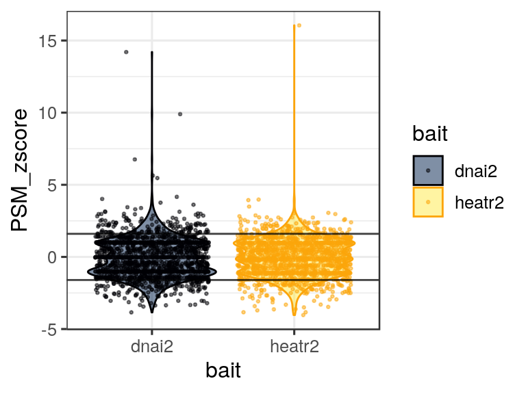

```r
ggplot(frog_combined, aes(x = bait, y = PSM_zscore, fill = bait, color = bait)) +
  geom_violin(alpha = 0.5) +
  geom_jitter(size = 0.5, alpha = 0.5) +   # overlay data points on distribution
  geom_hline(yintercept = 1.6, alpha = 0.75) +    # add lines at z-value cutoffs
  geom_hline(yintercept = -1.6, alpha = 0.75) +
  scale_color_viridis_d(option = "B", end = 0.8) +   # color data points
  scale_fill_viridis_d(option = "E")  # color distribution
```

### 1.3 Joining an experiment table with an annotation table

Now we have a dataframe that contains protein interaction data for both dnai2 and heatr2, but the actual identifiers in the `ID` are not informative. To investigate the interacting biology, we need to join an annotation table to the APMS dataframe. Download the annotations with the code chunk below.

```r
# download the frog gene annotations
frog_annotations <- read_csv("https://rachaelcox.github.io/classes/datasets/frog_enog_annotations.csv")
head(frog_annotations)
```

```
## # A tibble: 6 x 6
##   ID    OG_category XENLA_GeneNames HUMAN_GeneNames OG_annotation
##   <chr> <chr>       <chr>           <chr>           <chr>
## 1 ENOG… S           rhpn1.L, rhpn2… RHPN2P1, RHPN2… Rhophilin, R…
## 2 ENOG… S           arl14epl.L, ar… ARL14EPL        ADP-ribosyla…
## 3 ENOG… Z           myh1-2-1.S, my… MYH3, MYH7B     myosin, heav…
## 4 ENOG… S           loc101733025.L… SHISAL1         kiaa1644
## 5 ENOG… T           epha3.L, epha4… EPHA5, EPHA3, … Eph receptor
## 6 ENOG… O           txndc11.L       TXNDC11         thioredoxin …
## # … with 1 more variable: OG_category_annotation <chr>
```

Note that the annotation dataframe has an `ID` column that matches the `ID` column in the APMS dataframe. Also notice that the annotation dataframe has 14292 rows, and our APMS dataframe has 3356 rows. The `left_join()` function keeps all the rows from the dataframe used as the “left” input, while joining in places that match the common column (`ID` in this case) to the right dataframe. Use `left_join()` to combine the APMS dataframe with the annotation dataframe, such that the final data frame has 3356 rows and 12 columns.

```r
frog_combined_annotated <- frog_combined %>%
  left_join(frog_annotations, by = c("ID"))
head(frog_combined_annotated)
```

```
## # A tibble: 6 x 12
##   ID    ctrl_PSMs exp_PSMs PSM_fc PSM_log2fc PSM_zscore bait  OG_category
##   <chr>     <dbl>    <dbl>  <dbl>      <dbl>      <dbl> <chr> <chr>
## 1 ENOG…         0      202 200.        7.64       14.2  dnai2 Z
## 2 ENOG…        80      265   3.23      1.69        9.90 dnai2 I
## 3 ENOG…         0       46  46.2       5.53        6.76 dnai2 Z
## 4 ENOG…         1       35  17.7       4.15        5.64 dnai2 Z
## 5 ENOG…         9       52   5.21      2.38        5.47 dnai2 F
## 6 ENOG…        72      133   1.81      0.853       4.16 dnai2 C
## # … with 4 more variables: XENLA_GeneNames <chr>, HUMAN_GeneNames <chr>,
## #   OG_annotation <chr>, OG_category_annotation <chr>
```

Now each observation is connected to a *X. laevis* gene name, in addition to the gene’s human cousin. Not all genes have annotations, even though *X. laevis* is considered a model organism. This is common in bioinformatics.

**Bonus challenge:** Plot a bar chart with `OG_category_annotation` on the x-axis. Color by bait. Flip the chart so long descriptions are more readable using the `coord_flip()` layer. Try `facet_wrap()`, does this improve clarity? Remove the y-axis label.

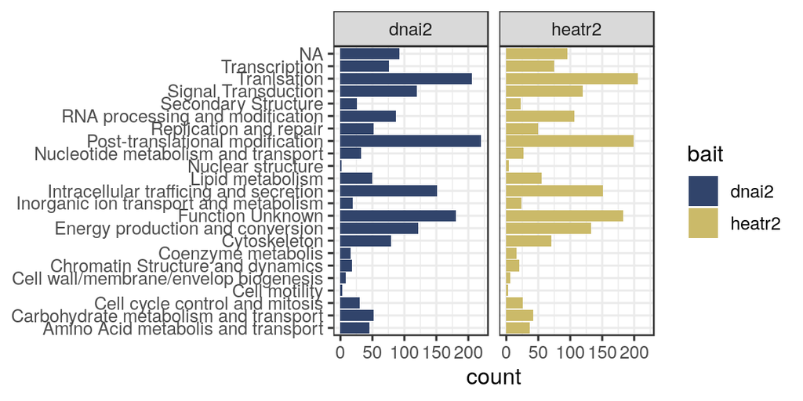

```r
ggplot(frog_combined_annotated, aes(x = OG_category_annotation, fill = bait)) +
  geom_bar(position = "dodge") +
  theme(axis.title.y = element_blank()) +
  facet_wrap(~bait) +
  scale_fill_viridis_d(option = "E", begin = 0.2, end = 0.8) +
  coord_flip()
```

## 2. Subsetting data (`filter()`, `select()`)

In biological data analysis, we’re often most interested in a specific subset of data–usually scores above some threshold (p-values, z-scores, fold changes in gene expression) or the behavior of a specific gene/protein family relative to time or different conditions.

Perform the following operations to pare down the combined APMS dataframe. Use the pipe (%>%) to save the results of operation to a new dataframe in a single step:

```r
frog_significant <- frog_combined_annotated %>%
  filter(PSM_zscore > 1.6) %>%
  select(-ctrl_PSMs, -exp_PSMs, -PSM_fc) %>%
  arrange(desc(PSM_zscore))
frog_significant
```

```
## # A tibble: 270 x 9
##    ID    PSM_log2fc PSM_zscore bait  OG_category XENLA_GeneNames
##    <chr>      <dbl>      <dbl> <chr> <chr>       <chr>
##  1 ENOG…      7.91       16.0  heat… S           dnaaf5.L, dnaa…
##  2 ENOG…      7.64       14.2  dnai2 Z           dnai2.S
##  3 ENOG…      1.69        9.90 dnai2 I           loc100494633.L…
##  4 ENOG…      5.53        6.76 dnai2 Z           dnai1.L
##  5 ENOG…      4.15        5.64 dnai2 Z           loc101730961.L…
##  6 ENOG…      2.38        5.47 dnai2 F           cps1.L, cad.L
##  7 ENOG…      0.853       4.16 dnai2 C           pc.S
##  8 ENOG…      0.582       4.02 dnai2 Z           tubb.S, tubb2b…
##  9 ENOG…      1.13        3.98 heat… J           gcn1.S, gcn1.L
## 10 ENOG…      1.42        3.94 heat… U           ipo7.L
## # … with 260 more rows, and 3 more variables: HUMAN_GeneNames <chr>,
## #   OG_annotation <chr>, OG_category_annotation <chr>
```

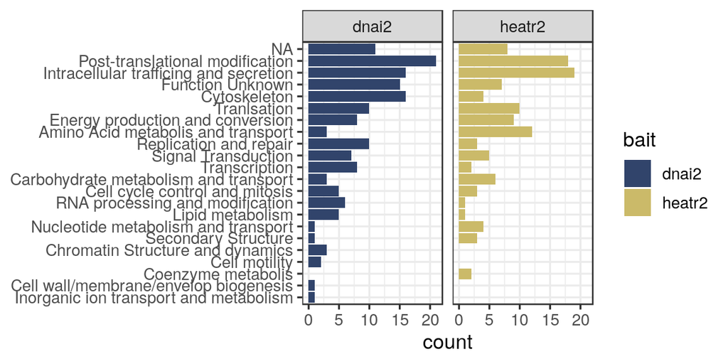

```r
ggplot(frog_significant, aes(x = fct_rev(fct_infreq(OG_category_annotation)),
                             fill = bait)) +
  geom_bar(position = "dodge") +
  theme(axis.title.y = element_blank()) +
  facet_wrap(~bait) +
  scale_fill_viridis_d(option = "E", begin = 0.2, end = 0.8) +
  coord_flip()
```

## 3. Aggregating data (`group_by()`, `summarize()`, `arrange()`)

To find broad patterns in big datasets, we can use the `group_by()` and `summarize()` functions to get summary information for groups of variables. For instance, the `bait` column has two groups: dnai2 and heatr2. The `OG_category_annotations` column has 22 groups if you count the “NA” values resulting from unannotated genes. Run the code below to see the groups.

```r
frog_significant$bait %>% unique()
```

```
## [1] "heatr2" "dnai2"
```

```r
frog_significant$OG_category_annotation %>% unique()
```

```
##  [1] "Function Unknown"
##  [2] "Cytoskeleton"
##  [3] "Lipid metabolism"
##  [4] "Nucleotide metabolism and transport"
##  [5] "Energy production and conversion"
##  [6] "Tranlsation"
##  [7] "Intracellular trafficing and secretion"
##  [8] "Amino Acid metabolis and transport"
##  [9] "Cell wall/membrane/envelop biogenesis"
## [10] NA
## [11] "Post-translational modification"
## [12] "Replication and repair"
## [13] "Carbohydrate metabolism and transport"
## [14] "Cell cycle control and mitosis"
## [15] "Chromatin Structure and dynamics"
## [16] "Signal Transduction"
## [17] "RNA processing and modification"
## [18] "Transcription"
## [19] "Secondary Structure"
## [20] "Cell motility"
## [21] "Inorganic ion transport and metabolism"
## [22] "Coenzyme metabolis"
```

When you `group_by()` a variable, you are collapsing all the information for the unique values associated with that variable. Then, we use `summarize()` to extract information associated with the collapsed information.

We want to learn the functional categories for the proteins that are most signficantly measured to be interacting with both dnai2 and heatr2. To do this, code the following steps (as a chain of functions connected by `%>%`):

1. Use `group_by()` to group both the `bait` and `OG_category_annotation` columns
2. Use `summarize()` to create a new column called `mean_zscore` that calculates the mean z-score for all the proteins in each category.
3. Use `arrange()` to sort the dataframe by `bait` and then by `mean_zscore` to get top hits.

```r
frog_final <- frog_significant %>%
  group_by(bait, OG_category_annotation) %>%
  summarize(mean_zscore = mean(PSM_zscore)) %>%
  arrange(bait, desc(mean_zscore))
head(frog_final)
```

```
## # A tibble: 6 x 3
## # Groups:   bait [1]
##   bait  OG_category_annotation                mean_zscore
##   <chr> <chr>                                       <dbl>
## 1 dnai2 Nucleotide metabolism and transport          5.47
## 2 dnai2 Cytoskeleton                                 3.64
## 3 dnai2 Lipid metabolism                             3.59
## 4 dnai2 Cell wall/membrane/envelop biogenesis        3.45
## 5 dnai2 Energy production and conversion             2.66
## 6 dnai2 Amino Acid metabolis and transport           2.55
```

Plot a bar chart for the functional categories, but this time put z-score on the y-axis instead of counts. Since you’re specifying the `y =` argument, you’ll have to use `geom_col()` instead of `geom_bar()`.

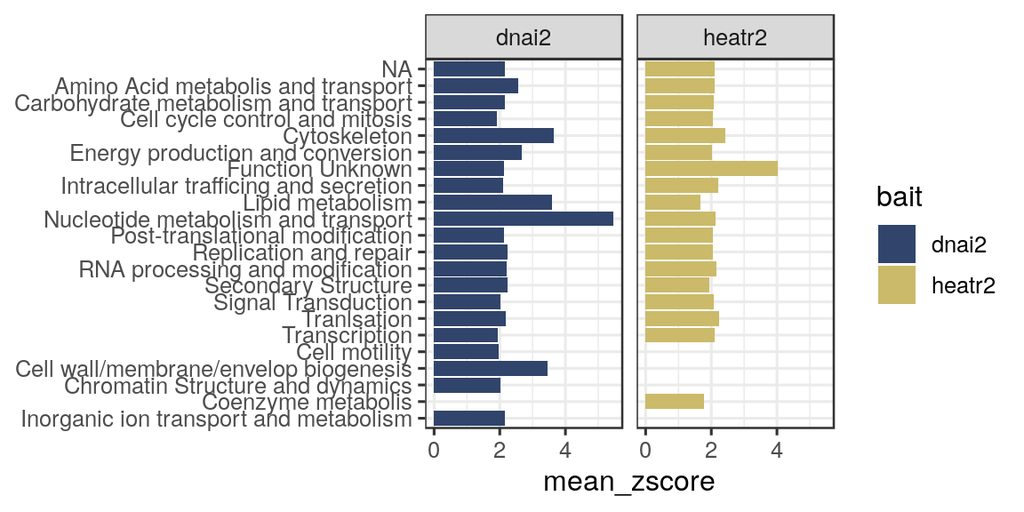

```r
ggplot(frog_final, aes(x = fct_rev(fct_infreq(OG_category_annotation)),
                       y = mean_zscore, fill = bait)) +
  geom_col(position = "dodge") +
  theme(axis.title.y = element_blank()) +
  facet_wrap(~bait) +
  scale_fill_viridis_d(option = "E", begin = 0.2, end = 0.8) +
  coord_flip()
```

## 4. If this was easy…

**Bonus challenge:** Take the sepal lengths from the `iris` dataset and put them into a wide table so that is one data column per species. You might be tempted to do this with the following code, which however doesn’t work. Can you explain why?

```r
# If you remove the # signs in the lines below you will get an error; this code doesn't work
# iris %>%
#   select(Sepal.Length, Species) %>%
#   pivot_wider(names_from = "Species", values_from = "Sepal.Length")
```

We can avoid this issue by adding a `row` column that is repeated among the three groups. This column simply counts rows within each group, from 1 to 50 in this particular data set. This trick forces the data from the same rows for different species into one row. (That means, rows 1 of setosa, versicolor, and virginica get combined, then rows 2, and so on.)

```r
iris %>%
  select(Sepal.Length, Species) %>%
  group_by(Species) %>%
  mutate(row = 1:n()) %>%
  pivot_wider(names_from = "Species", values_from = "Sepal.Length")
```

```
## # A tibble: 50 x 4
##      row setosa versicolor virginica
##    <int>  <dbl>      <dbl>     <dbl>
##  1     1    5.1        7         6.3
##  2     2    4.9        6.4       5.8
##  3     3    4.7        6.9       7.1
##  4     4    4.6        5.5       6.3
##  5     5    5          6.5       6.5
##  6     6    5.4        5.7       7.6
##  7     7    4.6        6.3       4.9
##  8     8    5          4.9       7.3
##  9     9    4.4        6.6       6.7
## 10    10    4.9        5.2       7.2
## # … with 40 more rows
```

(At the end, if you want, you can delete this column again:)

```r
iris %>%
  select(Sepal.Length, Species) %>%
  group_by(Species) %>%
  mutate(row = 1:n()) %>%
  pivot_wider(names_from = "Species", values_from = "Sepal.Length") %>%
  select(-row)
```

```
## # A tibble: 50 x 3
##    setosa versicolor virginica
##     <dbl>      <dbl>     <dbl>
##  1    5.1        7         6.3
##  2    4.9        6.4       5.8
##  3    4.7        6.9       7.1
##  4    4.6        5.5       6.3
##  5    5          6.5       6.5
##  6    5.4        5.7       7.6
##  7    4.6        6.3       4.9
##  8    5          4.9       7.3
##  9    4.4        6.6       6.7
## 10    4.9        5.2       7.2
## # … with 40 more rows
```

**Bonus challenge:** For the data set `diamonds` from the ggplot2 package, create a table displaying the mean price for each combination of cut and clarity. Then use `pivot_wider()` to rearrange this table into a wide format, such that there is a column of mean prices for each cut level (Fair, Good, Very Good, etc.).

```r
price_by_cut <-
  diamonds %>%
  group_by(cut, clarity) %>%
  summarize(mean.price = mean(price))
price_by_cut
```

```
## # A tibble: 40 x 3
## # Groups:   cut [5]
##    cut   clarity mean.price
##    <ord> <ord>        <dbl>
##  1 Fair  I1           3704.
##  2 Fair  SI2          5174.
##  3 Fair  SI1          4208.
##  4 Fair  VS2          4175.
##  5 Fair  VS1          4165.
##  6 Fair  VVS2         3350.
##  7 Fair  VVS1         3871.
##  8 Fair  IF           1912.
##  9 Good  I1           3597.
## 10 Good  SI2          4580.
## # … with 30 more rows
```

```r
price_by_cut %>%
  pivot_wider(names_from = "cut", values_from = "mean.price")
```

```
## # A tibble: 8 x 6
##   clarity  Fair  Good `Very Good` Premium Ideal
##   <ord>   <dbl> <dbl>       <dbl>   <dbl> <dbl>
## 1 I1      3704. 3597.       4078.   3947. 4336.
## 2 SI2     5174. 4580.       4989.   5546. 4756.
## 3 SI1     4208. 3690.       3932.   4455. 3752.
## 4 VS2     4175. 4262.       4216.   4550. 3285.
## 5 VS1     4165. 3801.       3805.   4485. 3490.
## 6 VVS2    3350. 3079.       3038.   3795. 3250.
## 7 VVS1    3871. 2255.       2459.   2831. 2468.
## 8 IF      1912. 4098.       4396.   3856. 2273.
```